# Simulaciones explicadas

Matias Baudino

2022-11-24

## Introducción

En este trabajo, utilizaremos datos históricos de los mundiales de futbol para simular los diferentes partidos de Quatar 2022 y obtener los resultados más probables en cada enfrentamiento. Para ello, generaremos las distribuciones de los goles que los equipos han hecho y han recibido.

## Dataset

El dataset seleccionado para estas simulaciones podran encontrarlo en la página de [Kaggle](https://www.kaggle.com/datasets/abecklas/fifa-world-cup).

De este Dataset utilizaremos unicamente el nombre del equipo local, los goles realizados por el equipo local y los goles recibidos. A la hora de generar las simulaciones haremos un par de supuestos en función de las distribuciones en cuanto al poder ofensivo y defensivo de cada equipo, y adaptaremos los resultados de forma acorde, es decir, si en una de las simulaciones un equipo hará 3 goles pero se enfrenta a un equipo que tiene un gran poder defensido y el mismo recibe solo 1, consideraremos entonces el promedio de los dos valores para la cantidad de goles que hará el equipo atacante, pero si el equipo que defiende no tiene un gran poder defensivo, el número de goles será el obtenido en la simulación.

```r
dataset <- read.csv("WorldCupMatches.csv")

head(dataset)
```

```
##   Year             Datetime   Stage        Stadium        City Home.Team.Name
## 1 1930 13 Jul 1930 - 15:00  Group 1        Pocitos Montevideo          France
## 2 1930 13 Jul 1930 - 15:00  Group 4 Parque Central Montevideo             USA
## 3 1930 14 Jul 1930 - 12:45  Group 2 Parque Central Montevideo      Yugoslavia
## 4 1930 14 Jul 1930 - 14:50  Group 3        Pocitos Montevideo         Romania
## 5 1930 15 Jul 1930 - 16:00  Group 1 Parque Central Montevideo       Argentina
## 6 1930 16 Jul 1930 - 14:45  Group 1 Parque Central Montevideo           Chile
##   Home.Team.Goals Away.Team.Goals Away.Team.Name Win.conditions Attendance
## 1               4               1         Mexico                      4444
## 2               3               0        Belgium                     18346
## 3               2               1         Brazil                     24059
## 4               3               1           Peru                      2549
## 5               1               0         France                     23409
## 6               3               0         Mexico                      9249
##   Half.time.Home.Goals Half.time.Away.Goals                Referee
```

[output cut: 20 more lines]

```r
datos_a_utilzar <- dataset %>%
  select(c(Home.Team.Name,
           Home.Team.Goals,
           Away.Team.Goals,
           Away.Team.Name))

head(datos_a_utilzar) %>%
  gt()
```

| Home.Team.Name | Home.Team.Goals | Away.Team.Goals | Away.Team.Name |
| --- | --- | --- | --- |
| France | 4 | 1 | Mexico |
| USA | 3 | 0 | Belgium |
| Yugoslavia | 2 | 1 | Brazil |
| Romania | 3 | 1 | Peru |
| Argentina | 1 | 0 | France |
| Chile | 3 | 0 | Mexico |

### Limpieza de datos

En el dataset, existen varios nombres de equipos que tienen errores de ortografía, como así también se necesita utilizar además los resultados obtenidos por los equipos visitantes, es decir, extraer la última columna y anexar esos datos al final del dataset.

```r
segunda_tanda <- datos_a_utilzar %>%
  select(c(Away.Team.Name,
           Away.Team.Goals,
           Home.Team.Goals,
           Home.Team.Name))

colnames(segunda_tanda) <- c("Home.Team.Name",
                             "Home.Team.Goals",
                             "Away.Team.Goals",
                             "Away.Team.Name")

head(segunda_tanda) %>%
  gt()
```

| Home.Team.Name | Home.Team.Goals | Away.Team.Goals | Away.Team.Name |
| --- | --- | --- | --- |
| Mexico | 1 | 4 | France |
| Belgium | 0 | 3 | USA |
| Brazil | 1 | 2 | Yugoslavia |
| Peru | 1 | 3 | Romania |
| France | 0 | 1 | Argentina |
| Mexico | 0 | 3 | Chile |

```r
datos_a_utilzar <- rbind(datos_a_utilzar,
                         segunda_tanda)
```

Ahora que los datos ya están completos para ser utilizados, revisaremos los nombres de los equipos con el fin de detectar anomalías que deberan ser corregidas.

```
##  [1] "France"                 "USA"                    "Yugoslavia"
##  [4] "Romania"                "Argentina"              "Chile"
##  [7] "Uruguay"                "Brazil"                 "Paraguay"
## [10] "Austria"                "Hungary"                "Switzerland"
## [13] "Sweden"                 "Germany"                "Spain"
## [16] "Italy"                  "Czechoslovakia"         "Cuba"
## [19] "England"                "Turkey"                 "Russia"
## [22] "Northern Ireland"       "Mexico"                 "Wales"
## [25] "Portugal"               "Korea DPR"              "Peru"
## [28] "Belgium"                "Bulgaria"               "Zaire"
## [31] "Poland"                 "Australia"              "Scotland"
## [34] "Netherlands"            "Haiti"                  "Tunisia"
## [37] "Algeria"                "Honduras"               "Canada"
## [40] "Morocco"                "South Korea"            "Iraq"
## [43] "Denmark"                "United Arab Emirates"   "Costa Rica"
## [46] "Cameroon"               "Republic of Ireland"    "Colombia"
## [49] "Norway"                 "Nigeria"                "Saudi Arabia"
## [52] "Bolivia"                "Greece"                 "Jamaica"
## [55] "South Africa"           "Japan"                  "Croatia"
## [58] "China"                  "Senegal"                "Slovenia"
## [61] "Ecuador"                "Trinidad and Tobago"    "Serbia and Montenegro"
## [64] "Angola"                 "Czech Republic"         "Togo"
## [67] "Iran"                   "Cï¿½te d'Ivoire"        "Ghana"
## [70] "Ukraine"                "Serbia"                 "New Zealand"
## [73] "Slovakia"               "Bosnia and Herzegovina" ""
## [76] "Egypt"                  "Dutch East Indies"      "Israel"
## [79] "El Salvador"            "Kuwait"
```

## Distribuciones

A continuación se presenta un ejemplo de las distribuciones que utilizaremos para cada equipo, es decir, en cada enfrentamiento se simularán cuantos goles puede hacer, como así también cuantos puede recibir cada equipo en la disputa, y en función de eso se computará el resultado siguiendo las reglas anteriormente descriptas.

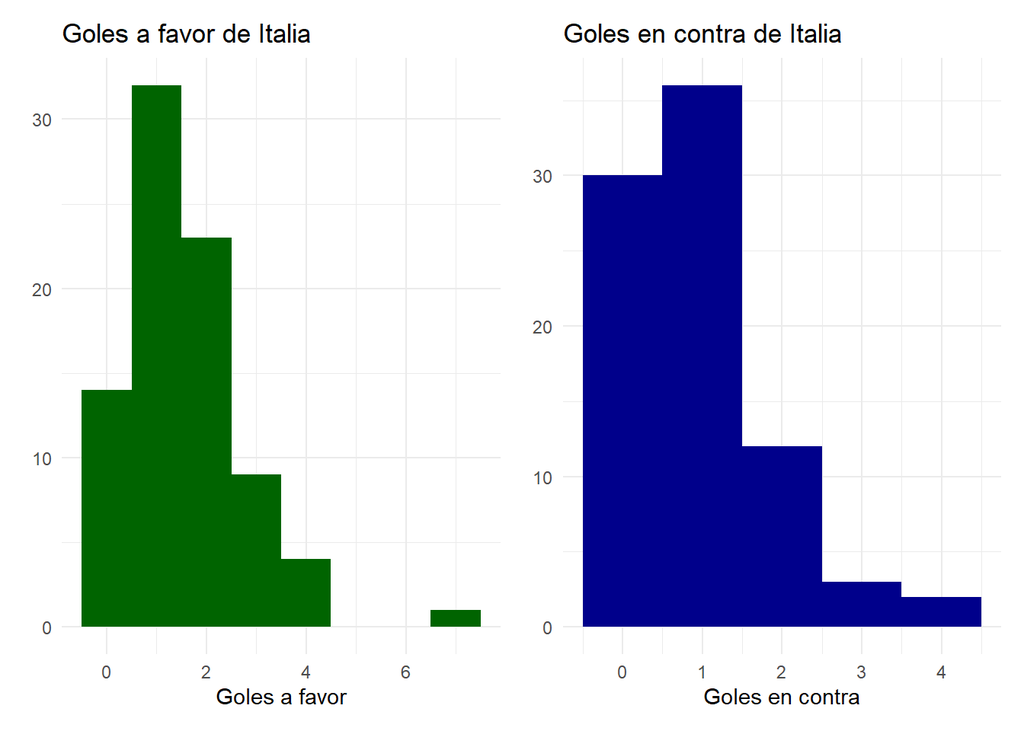

De esta distribuciones computaremos las medias y los desvios con el objetivo de utilizarlos para realizar las simulaciones. El dataset final con estos datos se muestra a continuación.

| Home.Team.Name | promedio_ofensivo | desvio_ofensivo | promedio_defensivo | desvio_defensivo |
| --- | --- | --- | --- | --- |
| Algeria | 1.0000000 | 1.2403473 | 1.5000000 | 0.7595545 |
| Angola | 0.3333333 | 0.5773503 | 0.6666667 | 0.5773503 |
| Argentina | 1.6419753 | 1.5191169 | 1.0493827 | 1.2134788 |
| Australia | 0.8461538 | 1.0681880 | 2.0000000 | 1.1547005 |
| Austria | 1.4827586 | 1.6173322 | 1.6206897 | 1.5216014 |
| Belgium | 1.2558140 | 1.0931175 | 1.5813953 | 1.3315326 |

## Simulaciones

### Definición de reglas para simulación

Para simular cada partido se computarán cuatro variables en cada partido:

1 - Los goles que puede hacer en promedio cada equipo. 2 - Los goles que puede recibir en promedio cada equipo.

A continuación se desarrolla la función que hará este computo.

### Función para simular partidos

Para simular los partidos se genera un loop que recorre el cronograma y va simulando uno a uno los encuentros utilizando las distribuciones obtenidas para cada equipo.

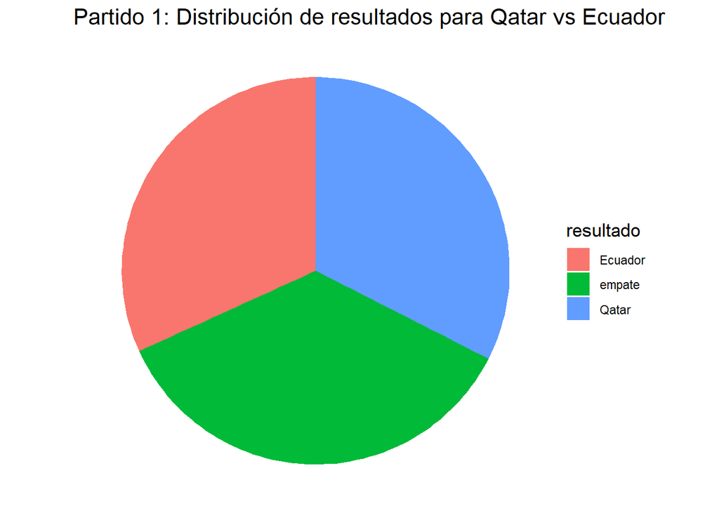

Top 5 resultados para Qatar vs Ecuador

| score_local | score_visitante | resultado | Count | probabilidad |
| --- | --- | --- | --- | --- |
| 0 | 0 | empate | 1883 | 18.83 |
| 1 | 0 | Qatar | 1500 | 15.00 |
| 0 | 1 | Ecuador | 1347 | 13.47 |
| 1 | 1 | empate | 1106 | 11.06 |
| 0 | 2 | Ecuador | 983 | 9.83 |

Probabilidades para Qatar vs Ecuador

| resultado | cnt | freq |
| --- | --- | --- |
| empate | 3566 | 0.357 |
| Qatar | 3252 | 0.325 |
| Ecuador | 3182 | 0.318 |

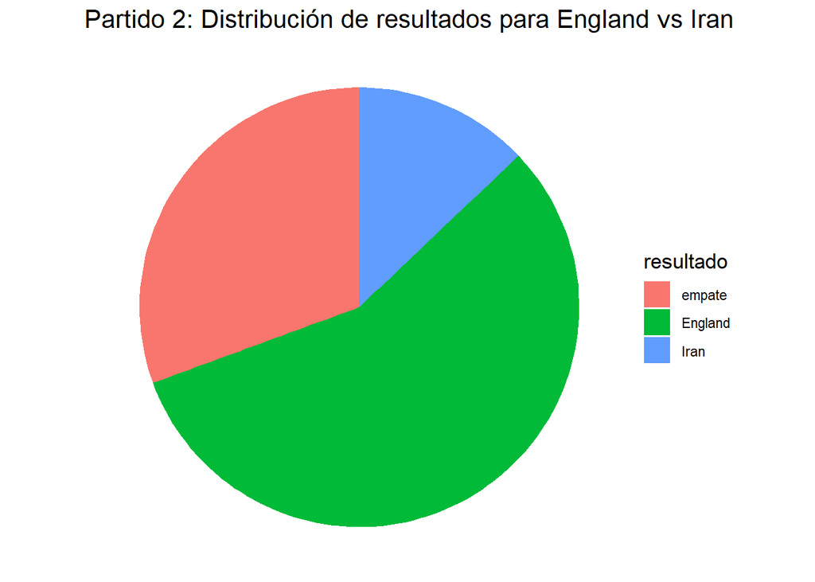

Top 5 resultados para England vs Iran

| score_local | score_visitante | resultado | Count | probabilidad |
| --- | --- | --- | --- | --- |
| 1 | 0 | England | 2108 | 21.08 |
| 2 | 0 | England | 1984 | 19.84 |
| 0 | 0 | empate | 1736 | 17.36 |
| 2 | 1 | England | 1135 | 11.35 |
| 1 | 1 | empate | 1107 | 11.07 |

Probabilidades para England vs Iran

| resultado | cnt | freq |
| --- | --- | --- |
| England | 5652 | 0.565 |
| empate | 3062 | 0.306 |
| Iran | 1286 | 0.129 |

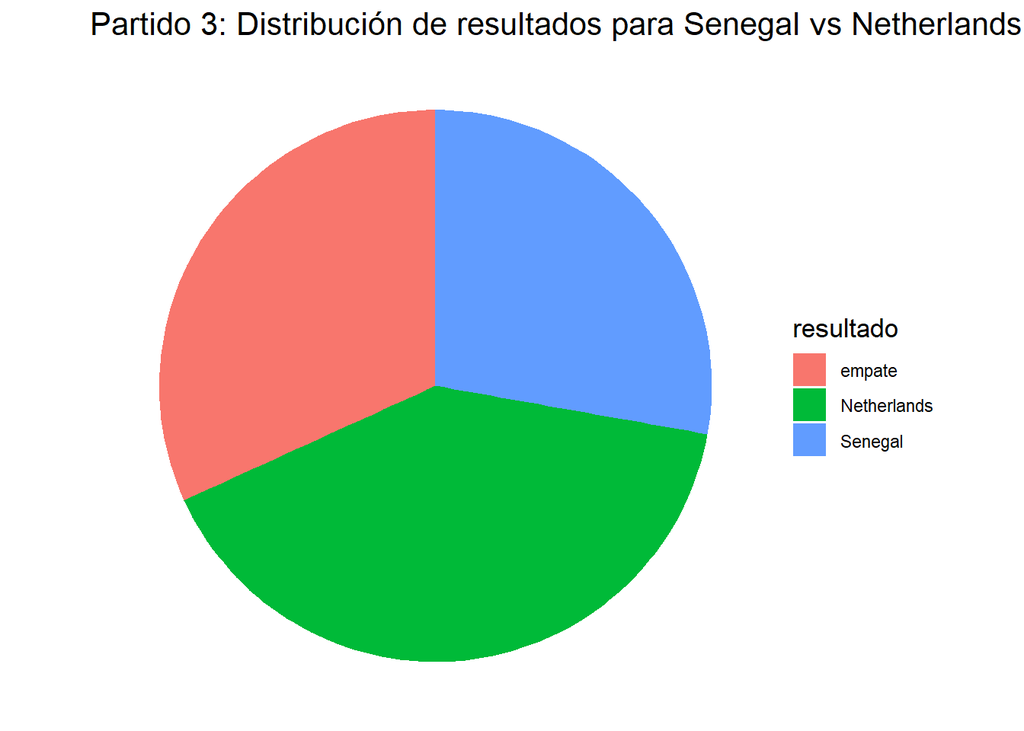

Top 5 resultados para Senegal vs Netherlands

| score_local | score_visitante | resultado | Count | probabilidad |
| --- | --- | --- | --- | --- |
| 2 | 2 | empate | 1499 | 14.99 |
| 0 | 2 | Netherlands | 1293 | 12.93 |
| 1 | 2 | Netherlands | 1268 | 12.68 |
| 2 | 1 | Senegal | 919 | 9.19 |
| 2 | 0 | Senegal | 897 | 8.97 |

Probabilidades para Senegal vs Netherlands

| resultado | cnt | freq |
| --- | --- | --- |
| Netherlands | 4040 | 0.404 |
| empate | 3184 | 0.318 |
| Senegal | 2776 | 0.278 |

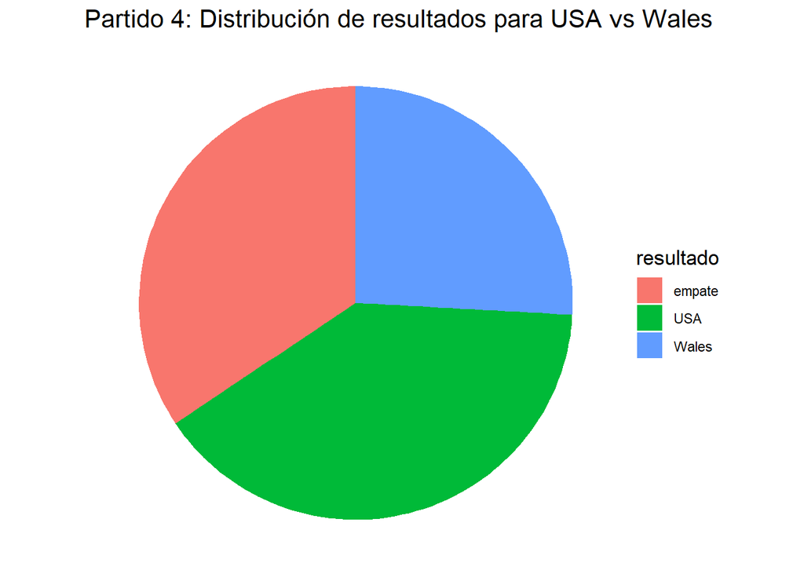

Top 5 resultados para USA vs Wales

| score_local | score_visitante | resultado | Count | probabilidad |
| --- | --- | --- | --- | --- |
| 1 | 0 | USA | 1746 | 17.46 |
| 0 | 0 | empate | 1530 | 15.30 |
| 1 | 1 | empate | 1469 | 14.69 |
| 0 | 1 | Wales | 1331 | 13.31 |
| 2 | 0 | USA | 1169 | 11.69 |

Probabilidades para USA vs Wales

| resultado | cnt | freq |
| --- | --- | --- |
| USA | 3977 | 0.398 |
| empate | 3437 | 0.344 |
| Wales | 2586 | 0.259 |

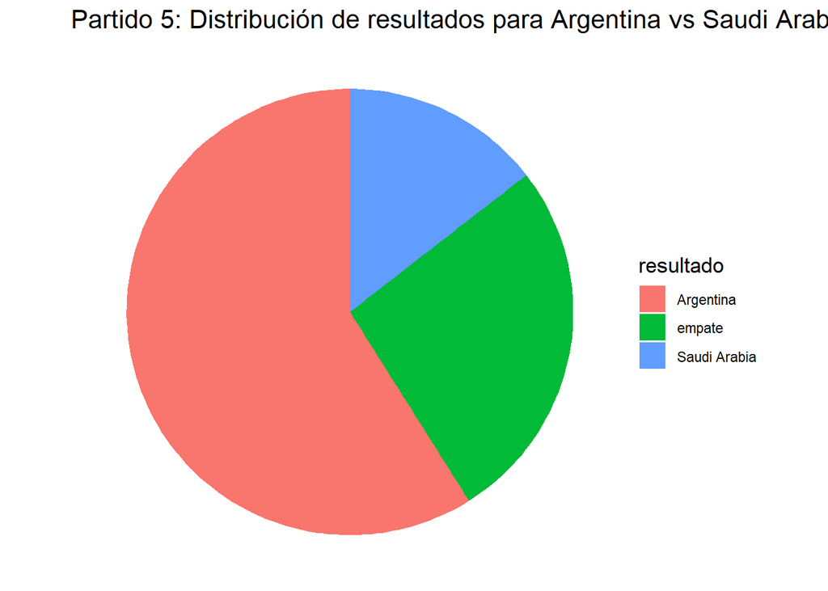

Top 5 resultados para Argentina vs Saudi Arabia

| score_local | score_visitante | resultado | Count | probabilidad |
| --- | --- | --- | --- | --- |
| 2 | 0 | Argentina | 1752 | 17.52 |
| 0 | 0 | empate | 1474 | 14.74 |
| 1 | 0 | Argentina | 1384 | 13.84 |
| 2 | 1 | Argentina | 1118 | 11.18 |
| 0 | 1 | Saudi Arabia | 853 | 8.53 |

Probabilidades para Argentina vs Saudi Arabia

| resultado | cnt | freq |
| --- | --- | --- |
| Argentina | 5896 | 0.590 |
| empate | 2656 | 0.266 |
| Saudi Arabia | 1448 | 0.145 |

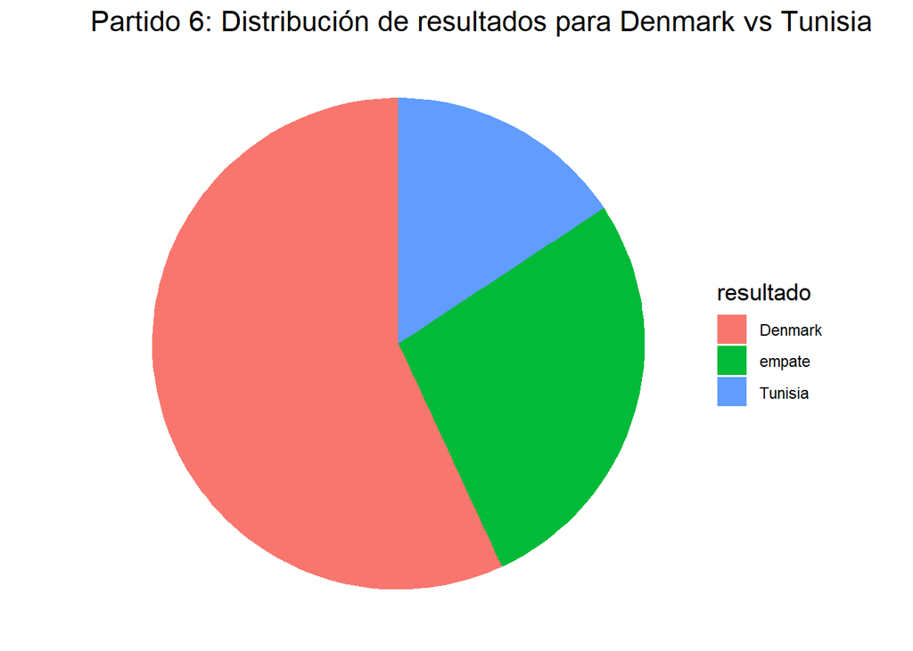

Top 5 resultados para Denmark vs Tunisia

| score_local | score_visitante | resultado | Count | probabilidad |
| --- | --- | --- | --- | --- |
| 2 | 0 | Denmark | 2248 | 22.48 |
| 2 | 1 | Denmark | 1414 | 14.14 |
| 0 | 0 | empate | 1279 | 12.79 |
| 1 | 0 | Denmark | 1234 | 12.34 |
| 1 | 1 | empate | 807 | 8.07 |

Probabilidades para Denmark vs Tunisia

| resultado | cnt | freq |
| --- | --- | --- |
| Denmark | 5690 | 0.569 |
| empate | 2742 | 0.274 |
| Tunisia | 1568 | 0.157 |

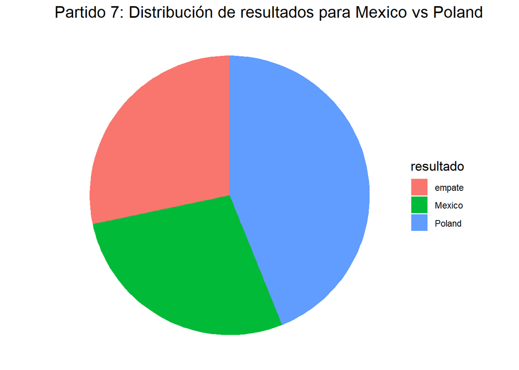

Top 5 resultados para Mexico vs Poland

| score_local | score_visitante | resultado | Count | probabilidad |
| --- | --- | --- | --- | --- |
| 0 | 0 | empate | 1408 | 14.08 |
| 1 | 0 | Mexico | 1190 | 11.90 |
| 0 | 2 | Poland | 1169 | 11.69 |
| 1 | 2 | Poland | 1073 | 10.73 |
| 2 | 0 | Mexico | 912 | 9.12 |

Probabilidades para Mexico vs Poland

| resultado | cnt | freq |
| --- | --- | --- |
| Poland | 4389 | 0.439 |
| empate | 2832 | 0.283 |
| Mexico | 2779 | 0.278 |

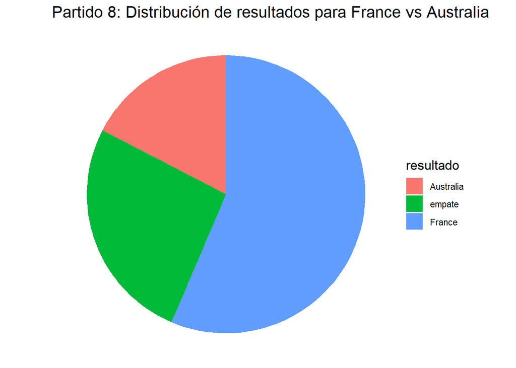

Top 5 resultados para France vs Australia

| score_local | score_visitante | resultado | Count | probabilidad |
| --- | --- | --- | --- | --- |
| 2 | 0 | France | 1750 | 17.50 |
| 2 | 1 | France | 1189 | 11.89 |
| 0 | 0 | empate | 1146 | 11.46 |
| 1 | 0 | France | 1056 | 10.56 |
| 2 | 2 | empate | 768 | 7.68 |

Probabilidades para France vs Australia

| resultado | cnt | freq |
| --- | --- | --- |
| France | 5639 | 0.564 |
| empate | 2617 | 0.262 |
| Australia | 1744 | 0.174 |

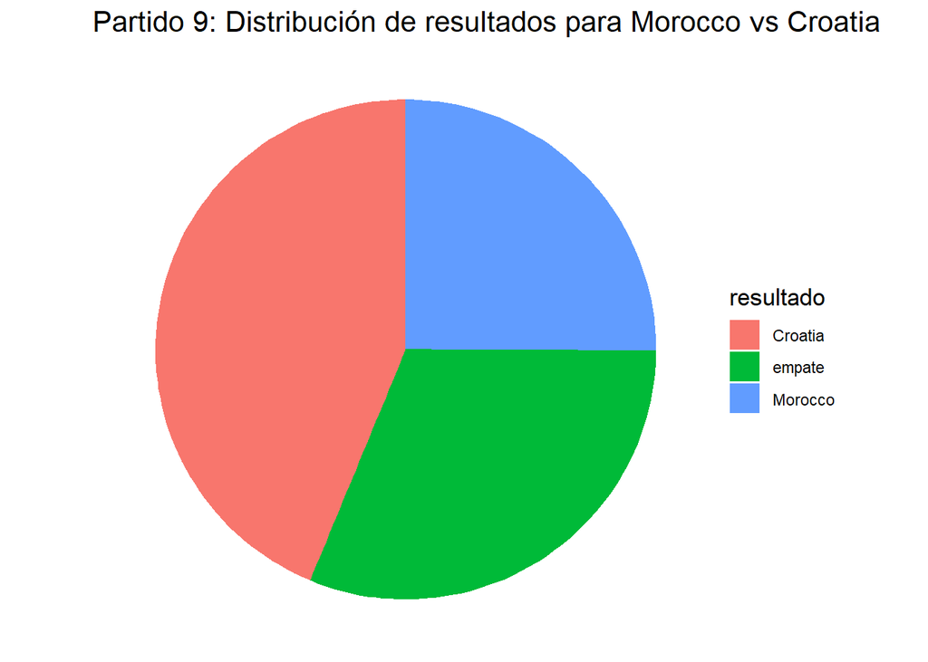

Top 5 resultados para Morocco vs Croatia

| score_local | score_visitante | resultado | Count | probabilidad |
| --- | --- | --- | --- | --- |
| 0 | 2 | Croatia | 1544 | 15.44 |
| 0 | 0 | empate | 1388 | 13.88 |
| 0 | 1 | Croatia | 1317 | 13.17 |
| 1 | 2 | Croatia | 1102 | 11.02 |
| 1 | 0 | Morocco | 1017 | 10.17 |

Probabilidades para Morocco vs Croatia

| resultado | cnt | freq |
| --- | --- | --- |
| Croatia | 4376 | 0.438 |
| empate | 3118 | 0.312 |
| Morocco | 2506 | 0.251 |

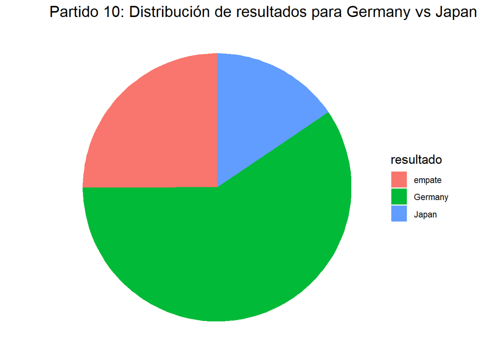

Top 5 resultados para Germany vs Japan

| score_local | score_visitante | resultado | Count | probabilidad |
| --- | --- | --- | --- | --- |
| 2 | 0 | Germany | 2033 | 20.33 |
| 2 | 1 | Germany | 1414 | 14.14 |
| 0 | 0 | empate | 1142 | 11.42 |
| 1 | 0 | Germany | 989 | 9.89 |
| 0 | 1 | Japan | 836 | 8.36 |

Probabilidades para Germany vs Japan

| resultado | cnt | freq |
| --- | --- | --- |
| Germany | 5944 | 0.594 |
| empate | 2505 | 0.250 |
| Japan | 1551 | 0.155 |

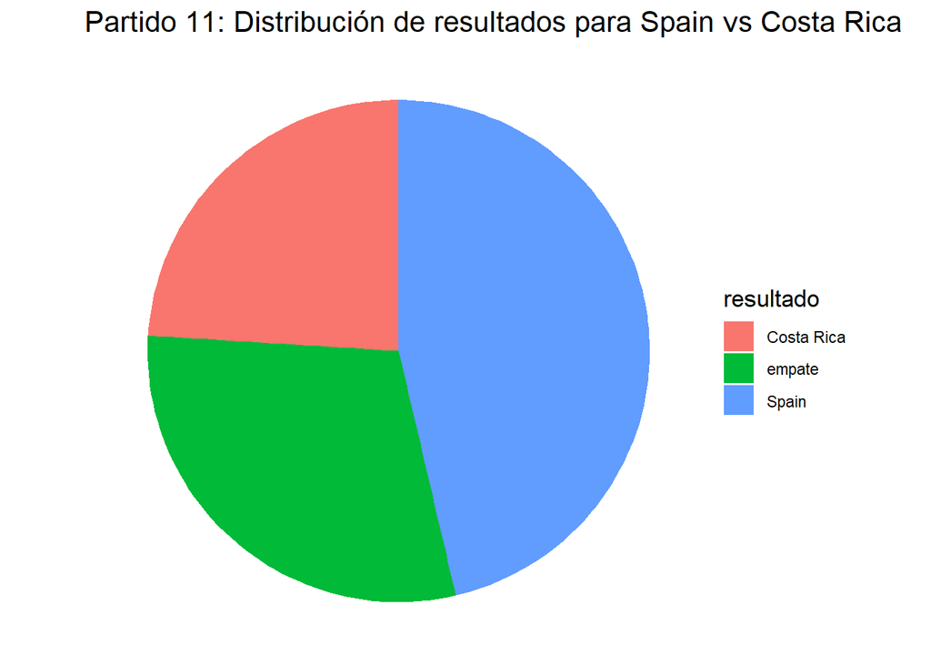

Top 5 resultados para Spain vs Costa Rica

| score_local | score_visitante | resultado | Count | probabilidad |
| --- | --- | --- | --- | --- |
| 2 | 0 | Spain | 1412 | 14.12 |
| 2 | 1 | Spain | 1309 | 13.09 |
| 0 | 0 | empate | 1141 | 11.41 |
| 1 | 0 | Spain | 1088 | 10.88 |
| 0 | 1 | Costa Rica | 1063 | 10.63 |

Probabilidades para Spain vs Costa Rica

| resultado | cnt | freq |
| --- | --- | --- |
| Spain | 4634 | 0.463 |
| empate | 2965 | 0.296 |
| Costa Rica | 2401 | 0.240 |

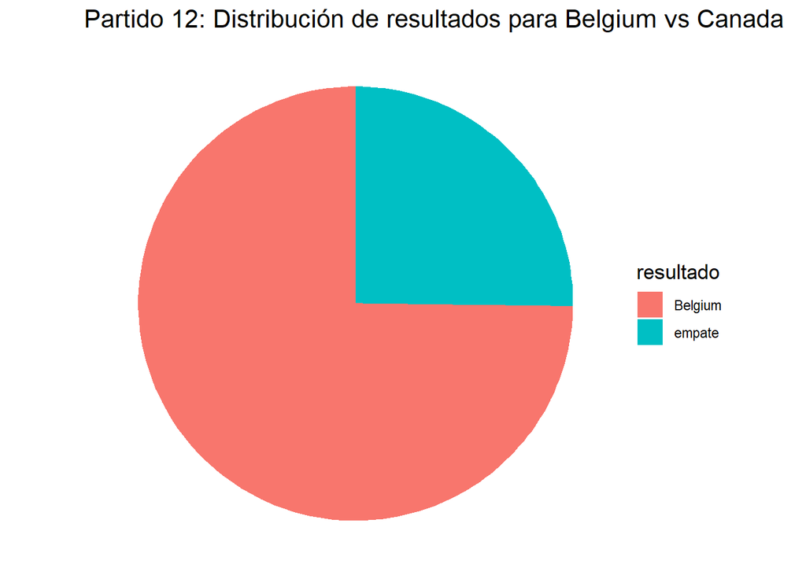

Top 5 resultados para Belgium vs Canada

| score_local | score_visitante | resultado | Count | probabilidad |
| --- | --- | --- | --- | --- |
| 2 | 0 | Belgium | 3837 | 38.37 |
| 1 | 0 | Belgium | 3442 | 34.42 |
| 0 | 0 | empate | 2524 | 25.24 |
| 3 | 0 | Belgium | 176 | 1.76 |
| 4 | 0 | Belgium | 21 | 0.21 |

Probabilidades para Belgium vs Canada

| resultado | cnt | freq |
| --- | --- | --- |
| Belgium | 7476 | 0.748 |
| empate | 2524 | 0.252 |

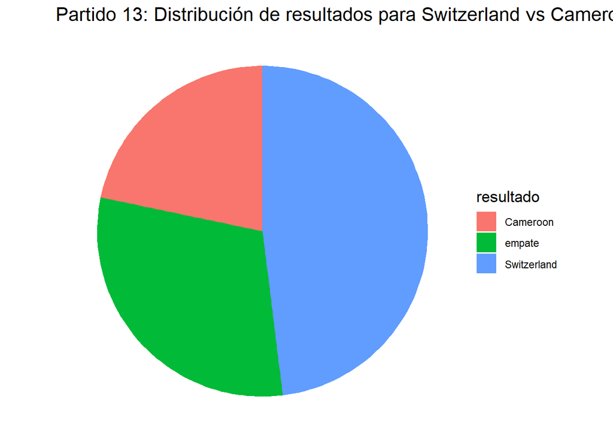

Top 5 resultados para Switzerland vs Cameroon

| score_local | score_visitante | resultado | Count | probabilidad |
| --- | --- | --- | --- | --- |
| 0 | 0 | empate | 1515 | 15.15 |
| 0 | 1 | Cameroon | 1440 | 14.40 |
| 2 | 0 | Switzerland | 1383 | 13.83 |
| 2 | 1 | Switzerland | 1284 | 12.84 |
| 1 | 0 | Switzerland | 1217 | 12.17 |

Probabilidades para Switzerland vs Cameroon

| resultado | cnt | freq |
| --- | --- | --- |
| Switzerland | 4805 | 0.480 |
| empate | 3022 | 0.302 |
| Cameroon | 2173 | 0.217 |

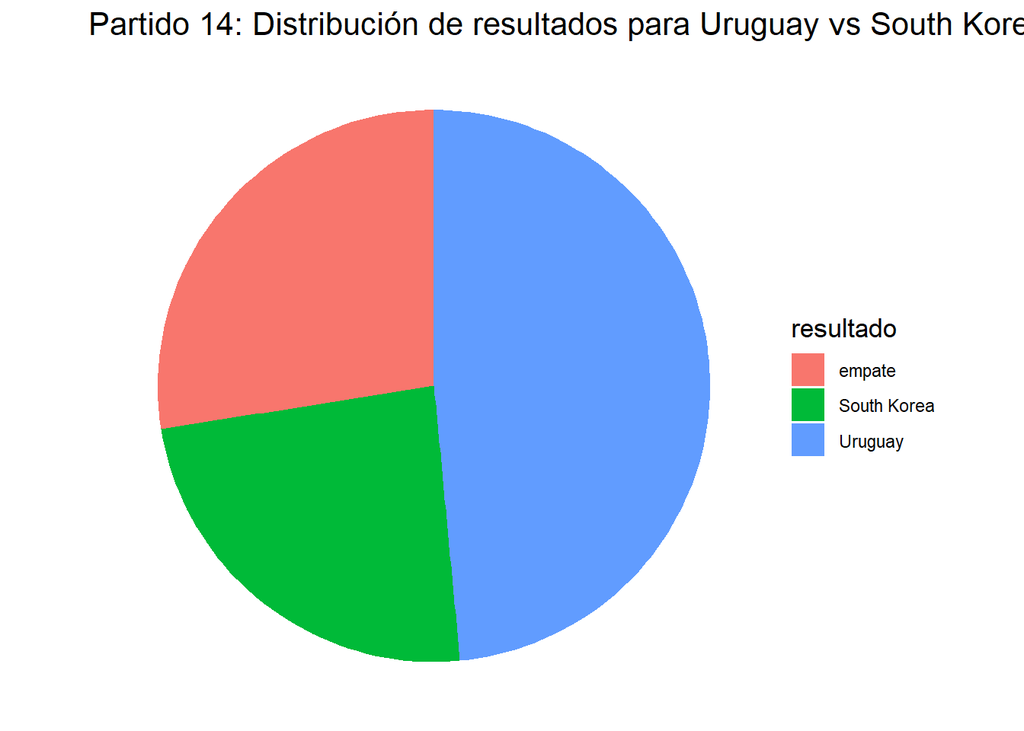

Top 5 resultados para Uruguay vs South Korea

| score_local | score_visitante | resultado | Count | probabilidad |
| --- | --- | --- | --- | --- |
| 0 | 0 | empate | 1279 | 12.79 |
| 0 | 1 | South Korea | 1272 | 12.72 |
| 2 | 0 | Uruguay | 1177 | 11.77 |
| 2 | 1 | Uruguay | 1176 | 11.76 |
| 1 | 1 | empate | 852 | 8.52 |

Probabilidades para Uruguay vs South Korea

| resultado | cnt | freq |
| --- | --- | --- |
| Uruguay | 4847 | 0.485 |
| empate | 2752 | 0.275 |
| South Korea | 2401 | 0.240 |

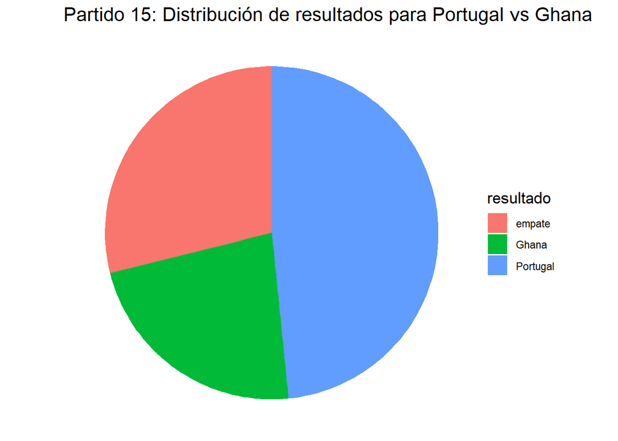

Top 5 resultados para Portugal vs Ghana

| score_local | score_visitante | resultado | Count | probabilidad |
| --- | --- | --- | --- | --- |
| 2 | 1 | Portugal | 1621 | 16.21 |
| 2 | 0 | Portugal | 1440 | 14.40 |
| 0 | 1 | Ghana | 1188 | 11.88 |
| 0 | 0 | empate | 1171 | 11.71 |
| 1 | 1 | empate | 869 | 8.69 |

Probabilidades para Portugal vs Ghana

| resultado | cnt | freq |
| --- | --- | --- |
| Portugal | 4838 | 0.484 |
| empate | 2889 | 0.289 |
| Ghana | 2273 | 0.227 |

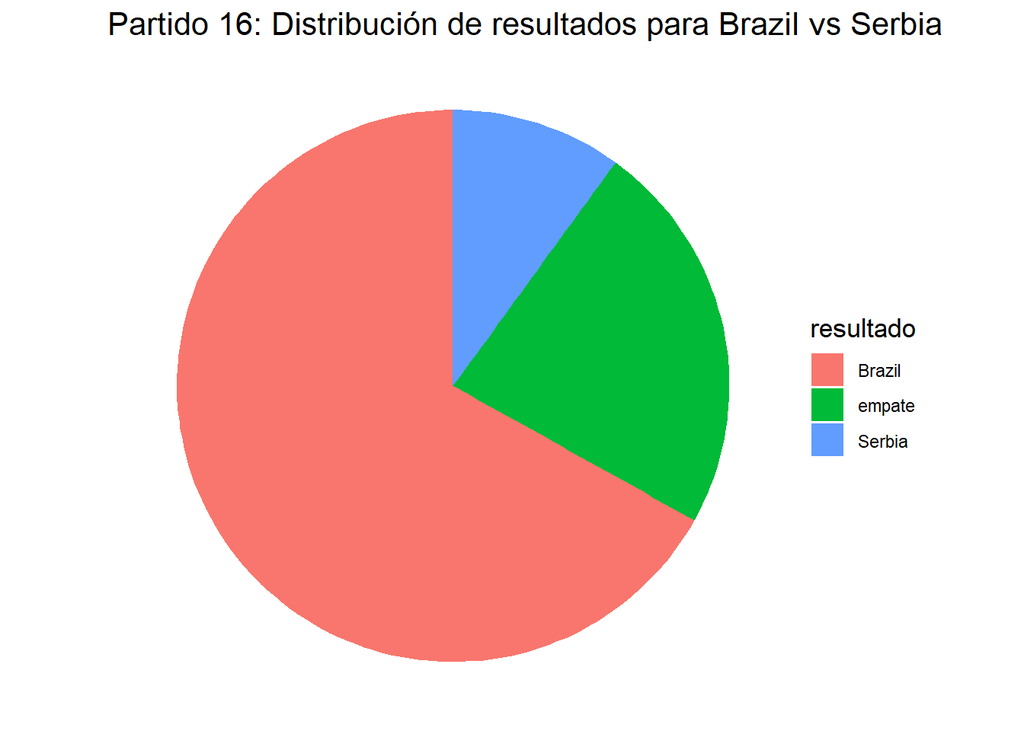

Top 5 resultados para Brazil vs Serbia

| score_local | score_visitante | resultado | Count | probabilidad |
| --- | --- | --- | --- | --- |
| 2 | 0 | Brazil | 2677 | 26.77 |
| 2 | 1 | Brazil | 1839 | 18.39 |
| 0 | 0 | empate | 1215 | 12.15 |
| 1 | 0 | Brazil | 1209 | 12.09 |
| 1 | 1 | empate | 863 | 8.63 |

Probabilidades para Brazil vs Serbia

| resultado | cnt | freq |
| --- | --- | --- |
| Brazil | 6694 | 0.669 |
| empate | 2306 | 0.231 |
| Serbia | 1000 | 0.100 |

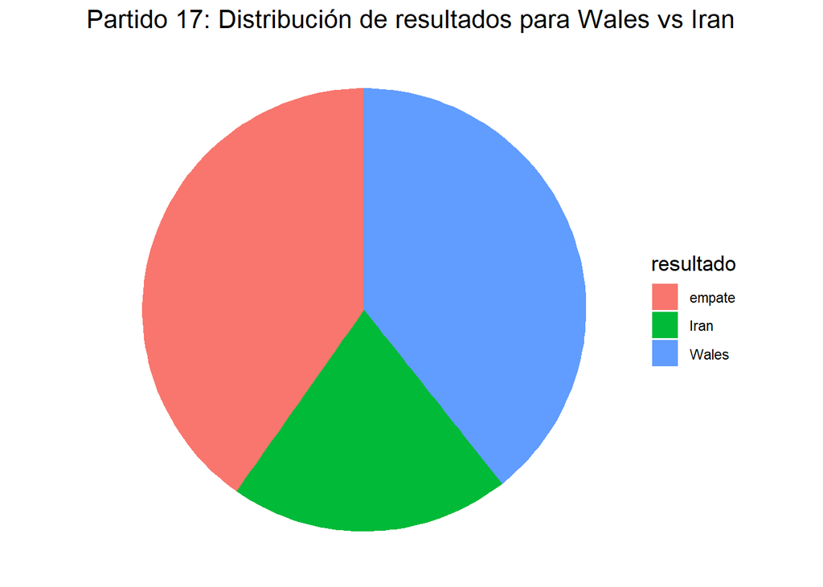

Top 5 resultados para Wales vs Iran

| score_local | score_visitante | resultado | Count | probabilidad |
| --- | --- | --- | --- | --- |
| 0 | 0 | empate | 2441 | 24.41 |
| 1 | 0 | Wales | 2248 | 22.48 |
| 0 | 1 | Iran | 1523 | 15.23 |
| 1 | 1 | empate | 1482 | 14.82 |
| 2 | 0 | Wales | 984 | 9.84 |

Probabilidades para Wales vs Iran

| resultado | cnt | freq |
| --- | --- | --- |
| empate | 4025 | 0.402 |
| Wales | 3934 | 0.393 |
| Iran | 2041 | 0.204 |

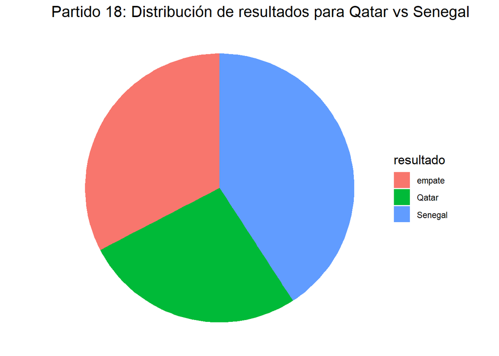

Top 5 resultados para Qatar vs Senegal

| score_local | score_visitante | resultado | Count | probabilidad |
| --- | --- | --- | --- | --- |
| 0 | 2 | Senegal | 1410 | 14.10 |
| 0 | 0 | empate | 1314 | 13.14 |
| 1 | 2 | Senegal | 1244 | 12.44 |
| 0 | 1 | Senegal | 1237 | 12.37 |
| 1 | 1 | empate | 1130 | 11.30 |

Probabilidades para Qatar vs Senegal

| resultado | cnt | freq |
| --- | --- | --- |
| Senegal | 4084 | 0.408 |
| empate | 3264 | 0.326 |
| Qatar | 2652 | 0.265 |

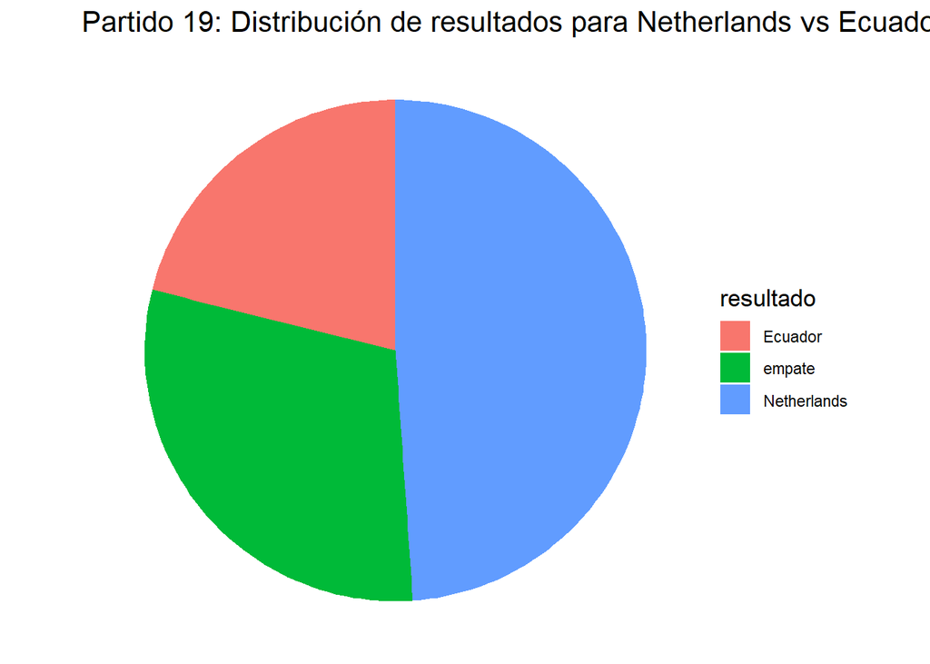

Top 5 resultados para Netherlands vs Ecuador

| score_local | score_visitante | resultado | Count | probabilidad |
| --- | --- | --- | --- | --- |
| 2 | 0 | Netherlands | 1807 | 18.07 |
| 2 | 1 | Netherlands | 1334 | 13.34 |
| 0 | 0 | empate | 1185 | 11.85 |
| 1 | 0 | Netherlands | 1178 | 11.78 |
| 2 | 2 | empate | 937 | 9.37 |

Probabilidades para Netherlands vs Ecuador

| resultado | cnt | freq |
| --- | --- | --- |
| Netherlands | 4888 | 0.489 |
| empate | 3005 | 0.300 |
| Ecuador | 2107 | 0.211 |

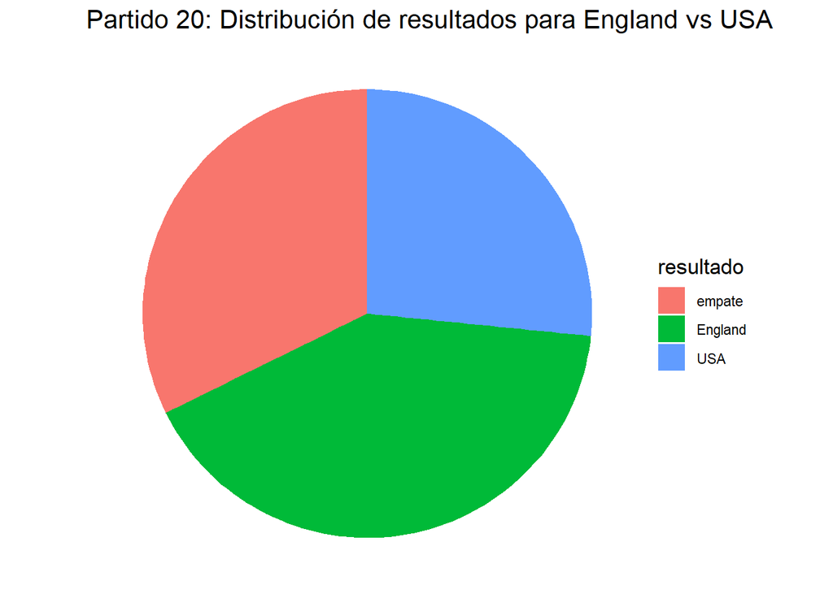

Top 5 resultados para England vs USA

| score_local | score_visitante | resultado | Count | probabilidad |
| --- | --- | --- | --- | --- |
| 1 | 0 | England | 1316 | 13.16 |
| 1 | 1 | empate | 1274 | 12.74 |
| 0 | 0 | empate | 1262 | 12.62 |
| 2 | 0 | England | 1209 | 12.09 |
| 0 | 1 | USA | 1117 | 11.17 |

Probabilidades para England vs USA

| resultado | cnt | freq |
| --- | --- | --- |
| England | 4107 | 0.411 |
| empate | 3232 | 0.323 |
| USA | 2661 | 0.266 |

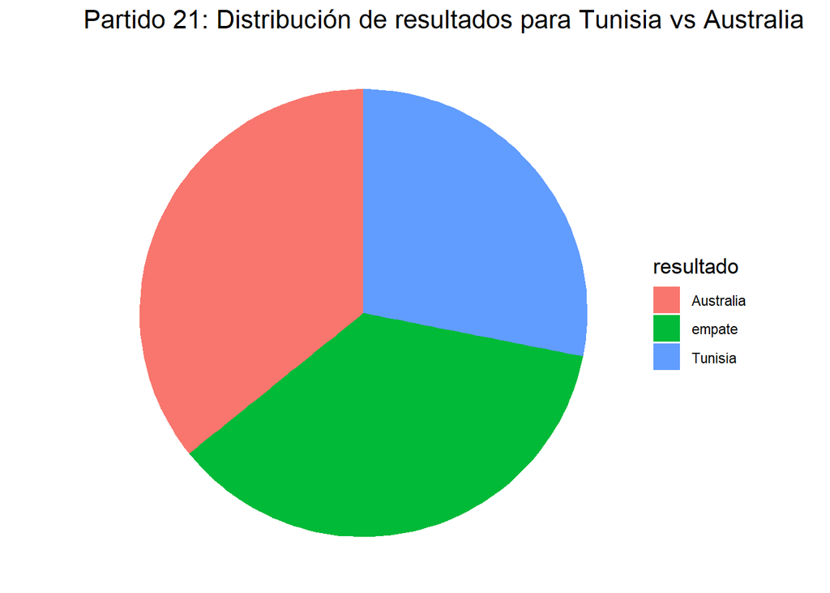

Top 5 resultados para Tunisia vs Australia

| score_local | score_visitante | resultado | Count | probabilidad |
| --- | --- | --- | --- | --- |
| 0 | 0 | empate | 1993 | 19.93 |
| 0 | 1 | Australia | 1547 | 15.47 |
| 1 | 0 | Tunisia | 1425 | 14.25 |
| 1 | 1 | empate | 1209 | 12.09 |
| 0 | 2 | Australia | 1120 | 11.20 |

Probabilidades para Tunisia vs Australia

| resultado | cnt | freq |
| --- | --- | --- |
| empate | 3613 | 0.361 |
| Australia | 3578 | 0.358 |
| Tunisia | 2809 | 0.281 |

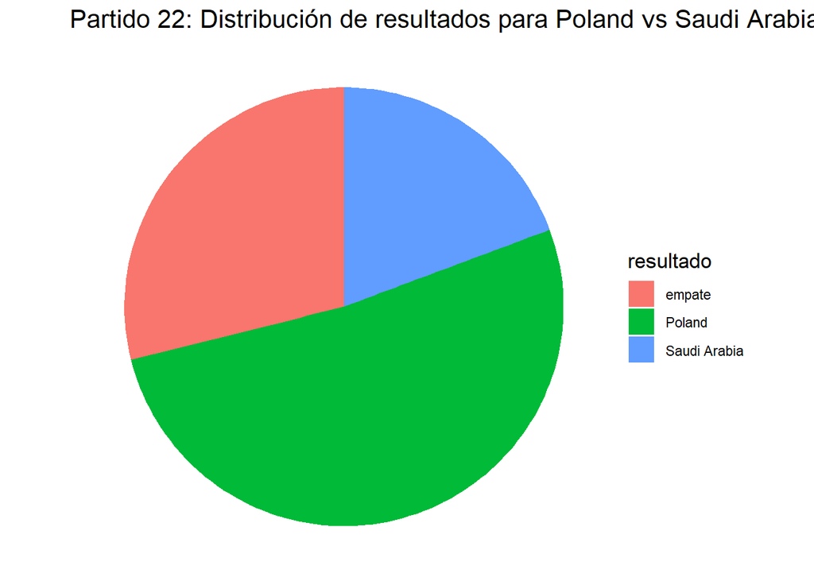

Top 5 resultados para Poland vs Saudi Arabia

| score_local | score_visitante | resultado | Count | probabilidad |
| --- | --- | --- | --- | --- |
| 0 | 0 | empate | 1819 | 18.19 |
| 2 | 0 | Poland | 1461 | 14.61 |
| 0 | 1 | Saudi Arabia | 1177 | 11.77 |
| 1 | 0 | Poland | 1138 | 11.38 |
| 2 | 1 | Poland | 937 | 9.37 |

Probabilidades para Poland vs Saudi Arabia

| resultado | cnt | freq |
| --- | --- | --- |
| Poland | 5179 | 0.518 |
| empate | 2891 | 0.289 |
| Saudi Arabia | 1930 | 0.193 |

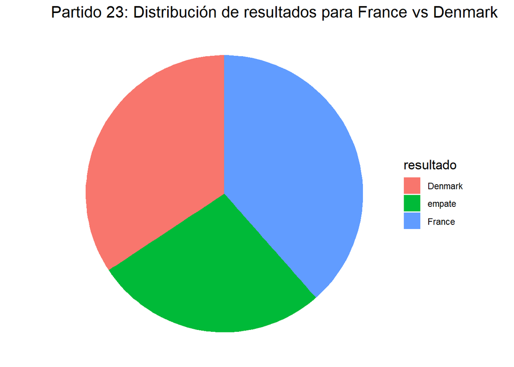

Top 5 resultados para France vs Denmark

| score_local | score_visitante | resultado | Count | probabilidad |
| --- | --- | --- | --- | --- |
| 2 | 2 | empate | 1452 | 14.52 |
| 0 | 2 | Denmark | 1141 | 11.41 |
| 2 | 0 | France | 1080 | 10.80 |
| 1 | 2 | Denmark | 947 | 9.47 |
| 2 | 1 | France | 941 | 9.41 |

Probabilidades para France vs Denmark

| resultado | cnt | freq |
| --- | --- | --- |
| France | 3851 | 0.385 |
| Denmark | 3427 | 0.343 |
| empate | 2722 | 0.272 |

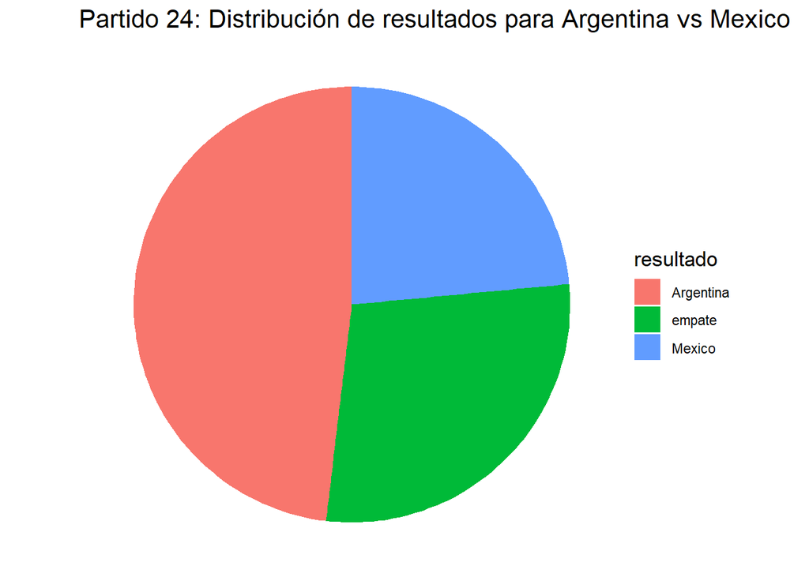

Top 5 resultados para Argentina vs Mexico

| score_local | score_visitante | resultado | Count | probabilidad |
| --- | --- | --- | --- | --- |
| 2 | 0 | Argentina | 1453 | 14.53 |
| 2 | 1 | Argentina | 1167 | 11.67 |
| 0 | 0 | empate | 1147 | 11.47 |
| 0 | 1 | Mexico | 980 | 9.80 |
| 1 | 0 | Argentina | 962 | 9.62 |

Probabilidades para Argentina vs Mexico

| resultado | cnt | freq |
| --- | --- | --- |
| Argentina | 4809 | 0.481 |
| empate | 2837 | 0.284 |
| Mexico | 2354 | 0.235 |

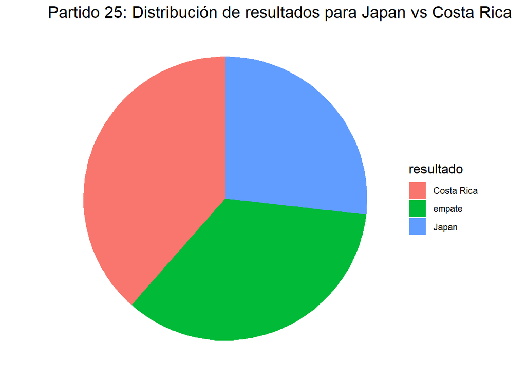

Top 5 resultados para Japan vs Costa Rica

| score_local | score_visitante | resultado | Count | probabilidad |
| --- | --- | --- | --- | --- |
| 0 | 1 | Costa Rica | 1827 | 18.27 |
| 0 | 0 | empate | 1766 | 17.66 |
| 1 | 0 | Japan | 1362 | 13.62 |
| 1 | 1 | empate | 1343 | 13.43 |
| 0 | 2 | Costa Rica | 1068 | 10.68 |

Probabilidades para Japan vs Costa Rica

| resultado | cnt | freq |
| --- | --- | --- |
| Costa Rica | 3846 | 0.385 |
| empate | 3469 | 0.347 |
| Japan | 2685 | 0.268 |

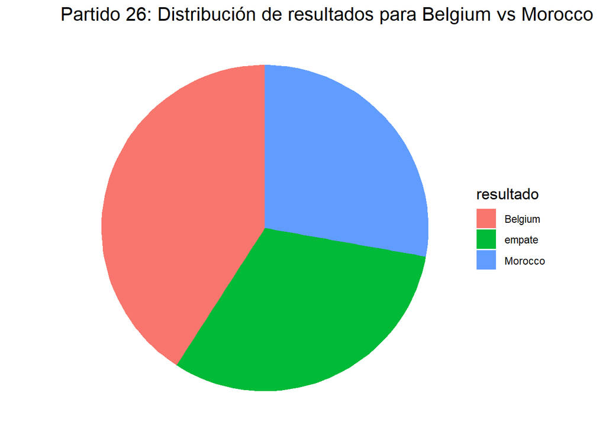

Top 5 resultados para Belgium vs Morocco

| score_local | score_visitante | resultado | Count | probabilidad |
| --- | --- | --- | --- | --- |
| 2 | 0 | Belgium | 1391 | 13.91 |
| 1 | 0 | Belgium | 1378 | 13.78 |
| 0 | 0 | empate | 1269 | 12.69 |
| 1 | 1 | empate | 1091 | 10.91 |
| 2 | 1 | Belgium | 1066 | 10.66 |

Probabilidades para Belgium vs Morocco

| resultado | cnt | freq |
| --- | --- | --- |
| Belgium | 4092 | 0.409 |
| empate | 3127 | 0.313 |
| Morocco | 2781 | 0.278 |

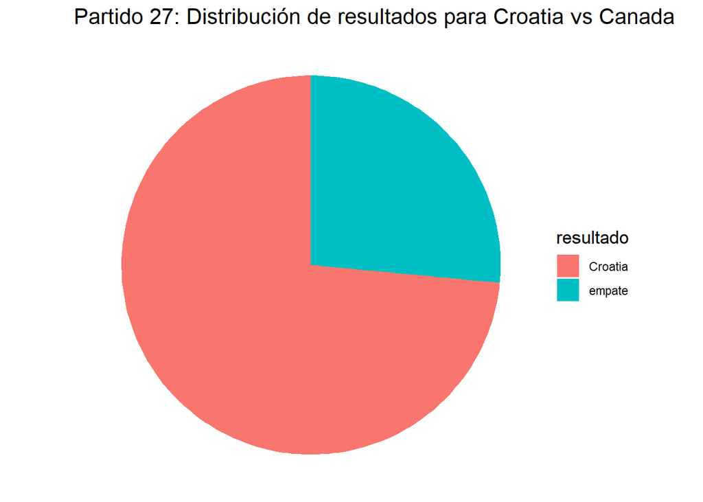

Top 5 resultados para Croatia vs Canada

| score_local | score_visitante | resultado | Count | probabilidad |
| --- | --- | --- | --- | --- |
| 2 | 0 | Croatia | 3974 | 39.74 |
| 1 | 0 | Croatia | 3042 | 30.42 |
| 0 | 0 | empate | 2652 | 26.52 |
| 3 | 0 | Croatia | 276 | 2.76 |
| 4 | 0 | Croatia | 56 | 0.56 |

Probabilidades para Croatia vs Canada

| resultado | cnt | freq |
| --- | --- | --- |
| Croatia | 7348 | 0.735 |
| empate | 2652 | 0.265 |

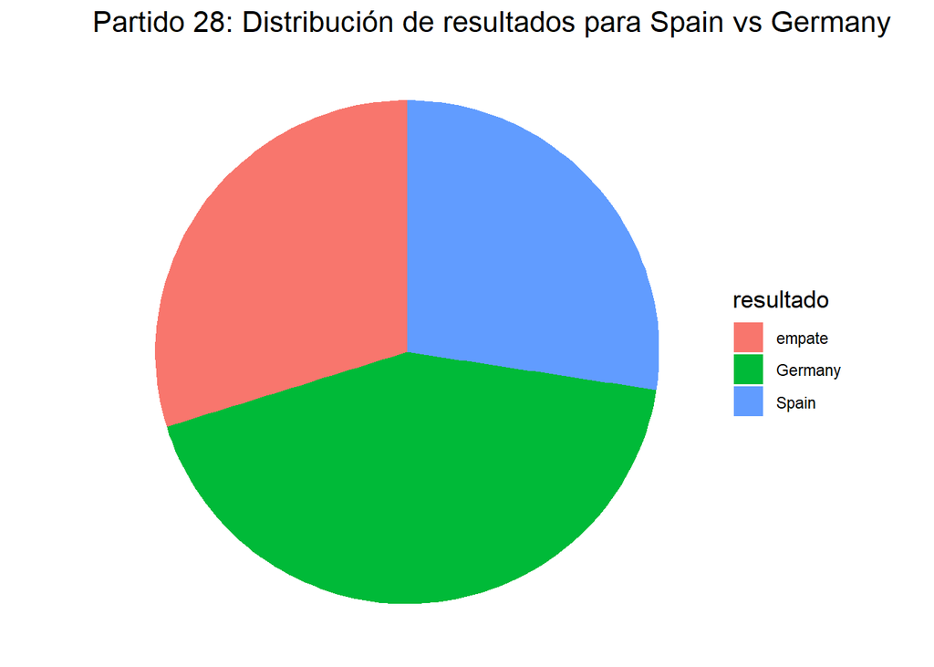

Top 5 resultados para Spain vs Germany

| score_local | score_visitante | resultado | Count | probabilidad |
| --- | --- | --- | --- | --- |
| 2 | 2 | empate | 1641 | 16.41 |
| 0 | 2 | Germany | 1231 | 12.31 |
| 1 | 2 | Germany | 1200 | 12.00 |
| 2 | 0 | Spain | 903 | 9.03 |
| 2 | 1 | Spain | 715 | 7.15 |